# Simulation-based decomposition

Chris Terry

```r
library(tidyverse)
library(brms)
library(knitr)
```

# Partitioning Framework

This script looks at how fluctuating environments impact coexistence predictions at each mean temperature. It broadly following Ellner et al (2019)’s https://onlinelibrary.wiley.com/doi/full/10.1111/ele.13159 simulation based method.

Given preceding analyses, I will just look at whether PAL is able in invade an equilibrium population of PAN, since this is the key transition of interest.

For each temperature will calculate the implied long-term growth rate (LGR,) under a variety of model scenarios. Here this will be referred to as $\bar{r}$, although we are in a discrete time model. Differences between these scenarios are used to define and calculate key partitions to identify the impact of various processes.

To simplify the partitioning will not include any of the fluctuations from expected stochasticity (modelled = the expectation, not a draw)

Compared to some alternatives, the baseline is assumed to be without any competitors, not just whether they fluctuate.

Working from the top-down (Letten et al. 2018, https://www.pnas.org/doi/full/10.1073/pnas.1801846115), first capture any ‘storage effects’, by breaking any covariance between the temperature and the number of the competitors

-$E$: PAL in competition under fluctuating temperatures (*correlated* between the two species)

-$D$: PAL in competition under fluctuating temperatures (uncorrelated between the two species)

-$\Delta_{cov}$ = $E-D$ (Additional effect of covariance in environment (~Storage Effect ))

To identify the core impact of competition $\Delta_C$ and fluctuations $\Delta_\sigma$, three further models are built:

-$A$ (Baseline): PAL in monoculture under fixed temperature

$$A = r_0$$

-$B$: PAL under competition (at fixed temperature ) and fixed temperature

$$B = r_0 + \Delta_C$$

-$C$: PAL in monoculture under fluctuating temperature

$$C = r_0 + \Delta_\sigma$$

-$r_0$ = Baseline growth

- $\Delta_*$ is an interaction term to allow:

$$D = r_0 + \Delta_C + \Delta_\sigma
+\Delta_*$$

Overall:

$$E = r_0 + \Delta_C + \Delta_\sigma
+\Delta_* +\Delta_{cov}$$

To accommodate the uncertainty in the parameters of the selected model, this is repeated for 1000 parameter draws.

# Simulation

Process at each temperature:

- Generate temperature regime
- Iterate PAN numbers in monoculture
- Discard burn-in period
- vector of PAL growth rates with these temperatures and PAN densities
- Calculate geometric average of PAL growth rates

Also calculating without variable temperature, to check variability is having an effect.

### Function to Calculate Partions for a given midpoint temperature.

```r
## Now using the models directly, not the parameters.

load( file=  '../AutoModels/KeyFits/FEMS_PAL_TP.Briere_Comp.BHTEMP1_Err.ZiNB_temp')
PAL_BEST_FIT <- PAL_TP.Briere_Comp.BHTEMP1_Err.ZiNB_temp_fit
load( file = '../AutoModels/KeyFits/FEMS_PAN_TP.Briere_Comp.BHTEMP1_Err.ZiNB_shapecomp')
PAN_BEST_FIT <-    PAN_TP.Briere_Comp.BHTEMP1_Err.ZiNB_shapecomp_fit

set.seed(1)
BRMS_DRAWS <- sample(1:8000, size = 1000, replace = FALSE) ## To mix across chains
```

```r
PrepData <-   function(df){
  df$Temp20 = df$PrevTemp -20

  df %>%
    mutate(Prev_PAL_FEMALE_comp = ifelse(Prev_PAL_FEMALE==0, 0, Prev_PAL_FEMALE-1),
           Prev_PAN_FEMALE_comp = ifelse(Prev_PAN_FEMALE==0, 0, Prev_PAN_FEMALE-1)) %>%
    return()
}


CalcPartions <- function( MidTemp = 25, BRMS_DRAWS =BRMS_DRAWS){

  ## Takes models from environment
  ## NB using r as shorthand for population growth rate (Nt/Nt+1, normally lambda), not as Instantaneous population growth rate

  ## It is as fast to call over all samples simultaneously, and pluck out just 1000 draws
  N = 1000


  R_past_tmax <- 0.1 ## need to pick a low non-zero number for  grwoth rate past tmax, or in case where getting negatives

  set.seed(1)
  Flucts <-   sample(c( -1.5, 0, 1.5), replace = TRUE, N) #  Generate Sequence of Temperatures
  TempSeq = rep(MidTemp, N)  +Flucts  # if no flucts, dynamics are stable => draws are stable
  TempSeq2 <- sample(TempSeq)  # randomise the time series to break any correlations

  ################################################
  #### Determining PAN monoculture trajectories
  ##########################
  ### PAN under steady temperature
  ###########
  PAN_Mat_steady = matrix(NA,nrow = N, ncol = 1000) # Rows = time, cols = draw from brms (1000)
  PAN_Mat_steady[1,] <- 20
  for(t in 2:20){  # Seems to steady well before 10, doubling for safety
    newdata =  data.frame(Prev_PAL_FEMALE =0,
                          Prev_PAN_FEMALE = PAN_Mat_steady[t-1,],
                          PrevTemp = MidTemp) %>%PrepData
    All_Predictions<- posterior_epred(PAN_BEST_FIT, draw_ids = BRMS_DRAWS, newdata)
    PAN_Mat_steady[t,] <-  diag(All_Predictions)
  #  print(t)
  #  matplot(PAN_Mat_steady, type = 'l')
  }
  PAN_Eqm_draws <- PAN_Mat_steady[20, ]

  #############################################
  ##### PAN under fluctuations

  PAN_Mat = matrix(NA,nrow = N, ncol = 1000) # Rows = time, cols = draw from brms (1000)
  PAN_Mat[1,] <- 10
  for(t in 2:N){
    newdata =  data.frame(Prev_PAL_FEMALE =0,
                          Prev_PAN_FEMALE = PAN_Mat[t-1,],
                          PrevTemp = TempSeq[t-1]) %>%PrepData

    All_Predictions<- posterior_epred(PAN_BEST_FIT, draw_ids = BRMS_DRAWS, newdata)
    PAN_Mat[t,] <-  diag(All_Predictions)
 #   print(t)
  }

#  matplot(PAN_Mat[,1:20], type = 'l')

  #####################
  # PAL growth rates (absolutely full model)
  ## Full Model (PAL invading from rare into monoculture of PAN, Correlated environment)
  PAL_GROWTH_Mat = matrix(NA,nrow = N, ncol = 1000) # Rows = time, cols = draw from brms (1000)
  for(t in 51:N){

    data.frame(Prev_PAL_FEMALE =1,
               Prev_PAN_FEMALE = PAN_Mat[t-1,],
               PrevTemp = TempSeq[t-1]) %>%
      PrepData %>%
      posterior_epred(PAL_BEST_FIT, draw_ids = BRMS_DRAWS,
                      newdata =. ) %>%
      diag() -> PAL_growths

    PAL_GROWTH_Mat[t-1,] <- PAL_growths
#    print(t)
  }

  PAL_GROWTH_Mat_NoBurn <-  PAL_GROWTH_Mat[50:(N-1), ]

   ## taking care of errors from overshooting tmax
  PAL_GROWTH_Mat_NoBurn[is.nan(PAL_GROWTH_Mat_NoBurn)] <- R_past_tmax
  PAL_GROWTH_Mat_NoBurn[PAL_GROWTH_Mat_NoBurn<R_past_tmax] <- R_past_tmax

#  matplot(PAL_GROWTH_Mat_NoBurn[,1:20], type = 'l')

  MeanGrowthRates_full <-   exp(colMeans(log(PAL_GROWTH_Mat_NoBurn)))  ## Geometric mean of growth rate

  #########################
  ##  PAL Growth Rates (No temp correlation model)
  #####
  PAL_GROWTH_Mat2 = matrix(NA,nrow = N, ncol = 1000) # Rows = time, cols = draw from brms (1000)

  for(t in 51:N){

    data.frame(Prev_PAL_FEMALE =1,
               Prev_PAN_FEMALE = PAN_Mat[t-1,],
               PrevTemp = TempSeq2[t-1]) %>%
      PrepData %>%
      posterior_epred(PAL_BEST_FIT, draw_ids = BRMS_DRAWS,
                      newdata =. ) %>%
      diag() -> PAL_growths
    PAL_GROWTH_Mat2[t-1,] <- PAL_growths
  #  print(t)
  }

  PAL_GROWTH_Mat2_NoBurn <-  PAL_GROWTH_Mat2[50:(N-1), ]

 ## taking care of errors from overshooting tmax
  PAL_GROWTH_Mat2_NoBurn[is.nan(PAL_GROWTH_Mat2_NoBurn)] <- R_past_tmax
    PAL_GROWTH_Mat_NoBurn[PAL_GROWTH_Mat_NoBurn<R_past_tmax] <- R_past_tmax

 # matplot(PAL_GROWTH_Mat2_NoBurn[,1:20], type = 'l')

  MeanGrowthRates_NoCorr <-   exp(colMeans(log(PAL_GROWTH_Mat2_NoBurn)))  ## Geometric mean of growth rate

  ############################
  ### PAL growth, no competition, no fluctuations
  ### (super simple... )
  data.frame(Prev_PAL_FEMALE =1,
             Prev_PAN_FEMALE = 0,
             PrevTemp = MidTemp) %>%
    PrepData %>%
    posterior_epred(PAL_BEST_FIT, draw_ids = BRMS_DRAWS,
                    newdata =. ) -> GrowthRates_NoFluct_NoComp

  ############################
  ### PAL growth, no competition, with fluctuations

  PAL_GROWTH_Mat3 = matrix(NA,nrow = N, ncol = 1000) # Rows = time, cols = draw from brms (1000)
  for(t in 2:N){
    data.frame(Prev_PAL_FEMALE =1,
               Prev_PAN_FEMALE =0,
               PrevTemp = TempSeq[t-1]) %>%
      PrepData %>%
      posterior_epred(PAL_BEST_FIT, draw_ids = BRMS_DRAWS,
                      newdata =. )  -> PAL_growths
    PAL_GROWTH_Mat3[t-1,] <- PAL_growths
   # print(t)
  }

  PAL_GROWTH_Mat3[is.nan(PAL_GROWTH_Mat3)] <- R_past_tmax
  PAL_GROWTH_Mat_NoBurn[PAL_GROWTH_Mat_NoBurn<R_past_tmax] <- R_past_tmax

 # matplot(PAL_GROWTH_Mat3[,1:50], type = 'l')
  MeanGrowthRates_NoComp_fluct <-   exp(colMeans(log(PAL_GROWTH_Mat3[-N,])))  ## Geometric mean of growth rate

    ############################
  ### PAL growth, with competition, no fluctuations (affecting either species)
  data.frame(Prev_PAL_FEMALE =1,
               Prev_PAN_FEMALE = PAN_Eqm_draws,
               PrevTemp = MidTemp) %>%
      PrepData %>%
      posterior_epred(PAL_BEST_FIT, draw_ids = BRMS_DRAWS,
                      newdata =. ) %>%
      diag() -> PAL_growths4
    GrowthRates_NoFluct_Comp <- PAL_growths4


    print(MidTemp)

  #######
  ### Combining
  data.frame( MidTemp = MidTemp,
              M.E_full = MeanGrowthRates_full,
              M.D_NoCorr = MeanGrowthRates_NoCorr,
              MBase = GrowthRates_NoFluct_NoComp,
              M.A_comp = GrowthRates_NoFluct_Comp,
              M.B_fluct = MeanGrowthRates_NoComp_fluct) %>%  ### NB changed label of models for the write-up!
    return()
}
```

### Testing functions

```r
Temp25_test<- CalcPartions(BRMS_DRAWS = BRMS_DRAWS, MidTemp = 27)
Temp25_test %>%
  pivot_longer(-MidTemp, names_to = 'Partition', values_to = 'Value') %>%
  ggplot( aes( x = Value, fill = Partition))+
  geom_histogram()+
  facet_wrap(~Partition)

Temp25_test %>%
  pivot_longer(-MidTemp, names_to = 'Partition', values_to = 'Value') %>%
  group_by(Partition) %>%
  summarise(median(Value ))
```

## Running over temperature range

```r
map_df(.x = seq(24, 27.6, by = 0.2),
       CalcPartions,
       BRMS_DRAWS = BRMS_DRAWS,
       .id = 'Temperature') -> Partition_over_Temp

write_csv(Partition_over_Temp,file =  '../Tables/SimulationPartitions.csv')
```

```r
Partition_over_Temp<- read_csv(file =  '../Tables/SimulationPartitions.csv')
Partition_over_Temp%>%
  select(-Temperature) %>%
  mutate( r0 =  MBase,
          Delta_cov  = M.E_full-M.D_NoCorr ,
          Delta_Comp = M.A_comp- MBase,
          Delta_Fluct= M.B_fluct- MBase,
          Delta_star = M.E_full - (MBase + Delta_Comp+Delta_Fluct+Delta_cov) ) %>%
  pivot_longer(-MidTemp, names_to = 'Partition', values_to = 'Value') %>%
  group_by(Partition, MidTemp) -> Partitions

## Model Outputs

Estimates_df <- data.frame(  Partition =c('M.E_full', 'M.A_comp' , 'M.B_fluct', 'MBase' ),
                             Estimate = c( 26.25,26.9,  NA, NA)) %>%
    mutate(Partition =fct_relevel(Partition,'M.E_full' ,'M.A_comp',  'M.B_fluct', 'MBase'))
```

## Examining Storage Effect

```r
## Storage Effect not relevant
Partitions %>%
  summarise(Median = median(Value )) %>% filter( Partition   == 'Delta_cov')
```

```
## # A tibble: 19 × 3
## # Groups:   Partition [1]
##    Partition MidTemp    Median
##    <chr>       <dbl>     <dbl>
##  1 Delta_cov    24    0.0121
##  2 Delta_cov    24.2  0.0101
##  3 Delta_cov    24.4  0.00799
##  4 Delta_cov    24.6  0.00614
##  5 Delta_cov    24.8  0.00441
##  6 Delta_cov    25    0.00269
##  7 Delta_cov    25.2  0.00109
##  8 Delta_cov    25.4 -0.000504
##  9 Delta_cov    25.6 -0.00193
## 10 Delta_cov    25.8 -0.00324
## 11 Delta_cov    26   -0.00433
## 12 Delta_cov    26.2 -0.00514
## 13 Delta_cov    26.4 -0.00481
## 14 Delta_cov    26.6 -0.00358
## 15 Delta_cov    26.8 -0.00455
## 16 Delta_cov    27   -0.00562
## 17 Delta_cov    27.2 -0.00673
## 18 Delta_cov    27.4 -0.00796
## 19 Delta_cov    27.6 NA
```

### Model Responses

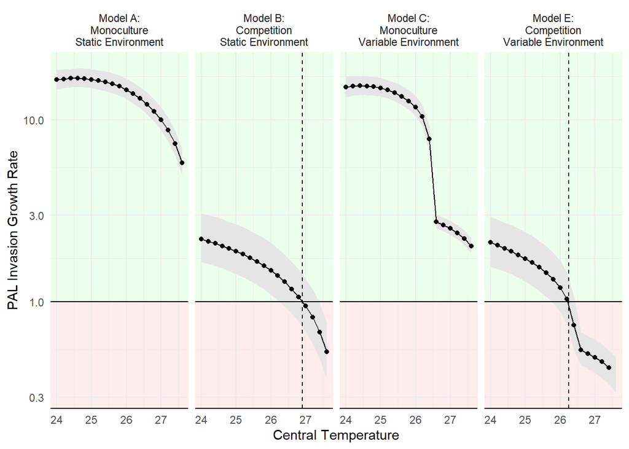

```r
Partitions  %>%
  filter( Partition   %in% c('M.E_full', 'MBase' , 'M.A_comp' , 'M.B_fluct' )) %>%
  summarise(Median = median(Value),
            Lower66 = quantile(Value,1/6, na.rm=TRUE),
            Upper66 = quantile(Value,5/6, na.rm=TRUE)) %>%
  ungroup() %>%
  mutate(Partition = fct_relevel(Partition ,'MBase','M.A_comp', 'M.B_fluct','M.E_full')) %>%
  ggplot( aes( x = MidTemp))+
  scale_y_log10()+
  geom_rect(xmin=0, xmax=30, ymin=log10(1), ymax=-1, fill = 'rosybrown1', alpha = 0.01)+
  geom_rect(xmin=0, xmax=30, ymin=log10(1), ymax=20, fill = 'darkseagreen1', alpha = 0.01)+
  geom_ribbon(aes(ymin = Lower66, ymax = Upper66), fill = 'grey90')+
  geom_point(aes( y =  Median))+
  geom_line(aes( y =  Median)) +
  geom_hline(yintercept = 0)+
  guides( col ='none')+
  facet_wrap(~Partition,
             nrow=1,
             ########################### Labeling of models modified to match paper!
             labeller = labeller(Partition=c('M.E_full' = 'Model E:\nCompetition\nVariable Environment',
                                             'M.A_comp' = 'Model B:\nCompetition\nStatic Environment',
                                             'M.B_fluct' ='Model C:\nMonoculture\nVariable Environment',
                                             'MBase'  ='Model A:\nMonoculture\nStatic Environment')))+
  ylab('PAL Invasion Growth Rate' )+ xlab('Central Temperature')+
  geom_vline(data = Estimates_df, aes(xintercept = Estimate), linetype =2)+
  theme_minimal()+
  geom_hline(yintercept = 1)-> Model_LGRs_Plots

Model_LGRs_Plots
```

## Partitions

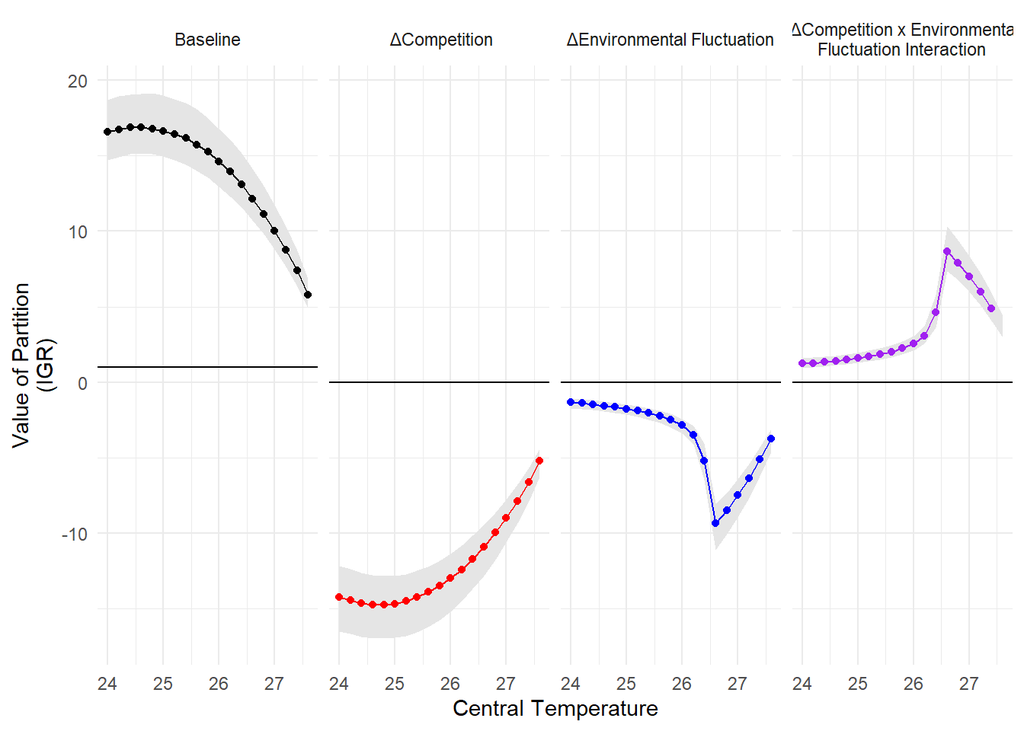

```r
Partitions  %>%
  filter( Partition   %in% c(  'r0', 'Delta_Comp' ,
                               'Delta_Fluct',  'Delta_star' )) %>%
  summarise(Median = median(Value),
            Lower66 = quantile(Value,1/6, na.rm=TRUE),
            Upper66 = quantile(Value,5/6, na.rm=TRUE)) %>%
  ungroup() %>%
    left_join(data.frame( Partition =c('r0', 'Delta_Comp' ,'Delta_Fluct',  'Delta_star' ),
                                Intercept = c(1, 0,0,0) ))%>%
  mutate(Partition = fct_relevel(Partition,'r0', 'Delta_Comp' ,'Delta_Fluct',  'Delta_star') ) %>%
  ggplot( )+
  geom_ribbon(aes(x = MidTemp, col = Partition, ymin = Lower66, ymax = Upper66), fill = 'grey90', linetype=0)+
  geom_point(aes( x = MidTemp, col = Partition, y =  Median))+
  geom_line(aes(x = MidTemp, col = Partition,   y =  Median)) +
  geom_hline(aes( yintercept = Intercept))+
  guides( col ='none')+
  facet_wrap(~Partition,
             nrow=1,
             labeller = labeller(Partition=c('r0' = 'Baseline',
                                             'Delta_Comp' = ' ΔCompetition',
                                             'Delta_Fluct' = 'ΔEnvironmental Fluctuation',
                                             'Delta_star'=' ΔCompetition x Environmental\nFluctuation Interaction')))+
  ylab('Value of Partition\n(IGR)' )+ xlab('Central Temperature')+
  theme_minimal()+
  scale_colour_manual(values = c('black','red', 'blue', 'purple'))-> PartitionsPlots

PartitionsPlots
```

## Combining Plots

```r
XX  <- cowplot::plot_grid( Model_LGRs_Plots,
                    PartitionsPlots, nrow=2, labels = c('a)', 'b)'))

ggsave('../Figures/Fig4_PartitionPlots.png', plot = XX, width = 8, height =6, bg = 'white')
```

# Interpolating Within Range of Predictions to find median and 66% intervals

```r
Partitions %>%
  filter( Partition == 'M.E_full' ) %>%
  mutate( Excluded = Value <1) %>%
  group_by(MidTemp) %>%
  summarise(FracExcl= mean( Excluded)) -> ExclDf
  kable(ExclDf)
```

| MidTemp | FracExcl |
| --- | --- |
| 24.0 | 0.002 |
| 24.2 | 0.003 |
| 24.4 | 0.004 |
| 24.6 | 0.006 |
| 24.8 | 0.008 |
| 25.0 | 0.012 |
| 25.2 | 0.029 |
| 25.4 | 0.054 |
| 25.6 | 0.091 |
| 25.8 | 0.189 |
| 26.0 | 0.290 |
| 26.2 | 0.451 |
| 26.4 | 0.783 |
| 26.6 | 0.987 |
| 26.8 | 0.992 |
| 27.0 | 0.993 |
| 27.2 | 0.997 |
| 27.4 | 0.997 |
| 27.6 | NA |

```r
 ## interpolate temperature:
interp<- approx( y = ExclDf$MidTemp, x = ExclDf$FracExcl, xout = c( 1/6, 0.5, 5/6)  )
interp
```

```
## $x
## [1] 0.1666667 0.5000000 0.8333333
##
## $y
## [1] 25.75442 26.22952 26.44935
```

```r
## Convert to generations:
(interp$y-23.6)/0.4
```

```
## [1] 5.386054 6.573795 7.123366
```